# HW5

require(corrplot) source(“http://www.sthda.com/upload/rquery_cormat.r”)

# Introduction

This script aims to create a model that will forecast an applicant’s future sales by finding relevant parameters from a data set including their age, experience, gpa, selling aptitude test score and anxiety test score.

# Data

First we look at the correlation matrix and pairwise scatterplots of given data

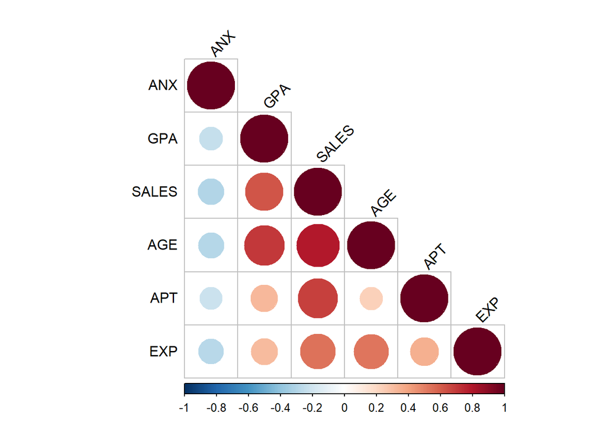

```
## $r
##         ANX  GPA SALES  AGE  APT EXP
## ANX       1
## GPA   -0.24    1
## SALES  -0.3 0.62     1
## AGE   -0.29  0.7  0.79    1
## APT   -0.22 0.32  0.68 0.23    1
## EXP   -0.28 0.31  0.54 0.53 0.35   1
##
## $p
##        ANX     GPA   SALES    AGE   APT EXP
## ANX      0
## GPA    0.2       0
## SALES  0.1 0.00028       0
## AGE   0.12 1.5e-05 1.9e-07      0
## APT   0.24   0.089 3.1e-05   0.22     0
## EXP   0.14    0.09  0.0019 0.0024 0.058   0
##
## $sym
##       ANX GPA SALES AGE APT EXP
## ANX   1
## GPA       1
## SALES     ,   1
## AGE       ,   ,     1
## APT       .   ,         1
## EXP       .   .     .   .   1
## attr(,"legend")
## [1] 0 ' ' 0.3 '.' 0.6 ',' 0.8 '+' 0.9 '*' 0.95 'B' 1
```

```r
rquery.cormat(data)
```

We are seeking to forecast sales figures and we can tell from the correlation matrix that all the variables except the anxiety test score - which has negative correlation- seemingly have a positive correlation with said figure.We need to inspect the pairwise scatterplots to see how relevant these numbers are.

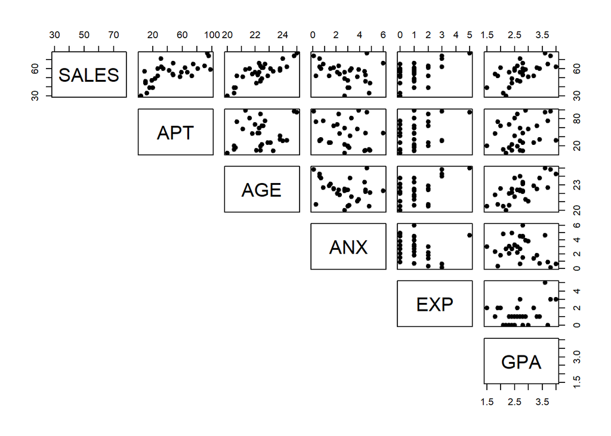

Although the correlation matrix shows that anxiety test scores and sales numbers have negative correlation, there is reasonable doubt that they might not necessarily correlate since there are enough outliers. The pairwise scatterplot of Experience level and sales numbers are also reason for doubt since the sample size for people with more than 3 years of experience is fairly small.

# Stepwise Regression

Initial_model <- lm(SALES~ AGE, data=data)

step1 <- lm(SALES~ AGE+ APT, data=data) #p=1e-08

step2 <- lm(SALES~ AGE+ ANX, data=data) #p=0.5

step3 <- lm(SALES~ AGE+ GPA, data=data) #p=0.46

step4 <- lm(SALES~ AGE+ EXP, data=data) #p=0.2

anova(Initial_model, step1)

Second_model <-lm(SALES~ AGE+ APT, data=data)

reduced <- lm(SALES~ APT, data=data)

anova(Second_model, reduced) #p=7.9e-11

step2.1 <-lm(SALES~ AGE+ APT+GPA, data=data) #p=0.66

step2.2 <-lm(SALES~ AGE+ APT+ANX, data=data) #p=0.9

step2.3 <-lm(SALES~ AGE+ APT+EXP, data=data) #p=0.95

anova(Second_model, step2.3)

Third_model <-lm(SALES~ AGE+ APT+GPA, data=data)

reduced2.1 <- lm(SALES~ APT+GPA, data=data) #p=3.58e-08

reduced2.2 <-lm(SALES~ AGE+GPA, data=data) #p=2.233e-08

anova(Third_model, reduced2.2)

step3.1 <- lm(SALES~ AGE+ APT+GPA+ANX, data=data) #p=0.9

step3.2 <- lm(SALES~ AGE+ APT+GPA+EXP, data=data) #p=0.98

anova(Third_model, step3.2)

Fourth_model <- lm(SALES~ AGE+ APT+GPA+ANX, data=data)

reduced3.1 <- lm(SALES~ AGE+ APT+ANX, data=data) #p=0.6

reduced3.2<-lm(SALES~ AGE+ GPA+ANX, data=data) #p=5.04e-08

reduced3.3<-lm(SALES~ APT+GPA+ANX, data=data) #p=8.2e-08

anova(Fourth_model, reduced3.3)

Reduced_fourth_model <-lm(SALES~ AGE+ APT+ANX, data=data)

step4.1 <-lm(SALES~ AGE+ APT+ANX+EXP, data=data) #p=0.94

anova(Reduced_fourth_model, step4.1)

Fifth_model <-lm(SALES~ AGE+ APT+ANX+EXP, data=data)

reduced4.1 <-lm(SALES~ APT+ANX+EXP, data=data) #p=8.4e-09

reduced4.2 <- lm(SALES~ AGE+ +ANX+EXP, data=data) #p=8.3e-08

reduced4.3 <-lm(SALES~ AGE+ APT+EXP, data=data) #p=0.9

anova(Fifth_model, reduced4.3)

Reduced_fifth_model<-lm(SALES~ AGE+ APT+EXP, data=data)

reduced5.1<-lm(SALES~ AGE+ APT, data=data) #p=0.95

reduced5.2 <-lm(SALES~ AGE+EXP, data=data) #p=4e-08

reduced5.3 <-lm(SALES~ APT+EXP, data=data) #p=3.3e-09

anova(Reduced_fifth_model, reduced5.3)

Final_model <-lm(SALES~ AGE+ APT, data=data)

Final model intercept=-83.8, coeff=[5.7,0.2]

# Step function

Object <-lm(SALES~ EXP+GPA+ANX+AGE+APT, data=data)

step(Object)

formula=>(Sales=AGE+APT),Intercept=-83.8, coeff=(5.7,0.2)

# GPA Significance

Gpa_model <-lm(SALES~ GPA+AGE+APT, data=data) anova(Final_model,Gpa_model) #p.06

# Result

H0= GPA of an applicant is irrelevant for sales figures

H1= GPA of an applicant is not irrelevant for sales figures

Pvalue=0.6

Probability of obtaining results as extreme as we did under h0 is %60 which is not enough to reject h0 so we can conclude that an applicants gpa is irrelevant

data <- read.table(“C:\Users\bjkse\Desktop\HW5\sales.txt”, header=T)